# Tips and Tricks with Jupyter Notebooks

## Part 2: Package Management

1. View descriptions for installed modules
2. Working with Tools for installing Modules
3. Tackling interdependencies -> Advanced topic
4. Outputting Requirements
5. Installing Requirements

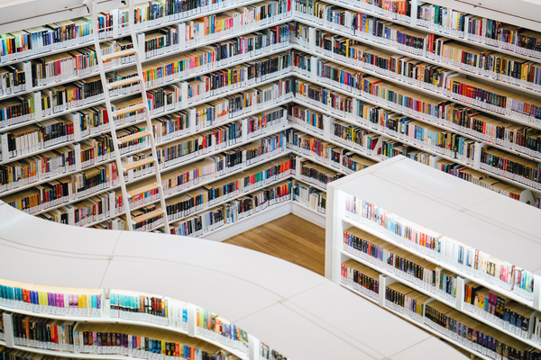

```python
from image_renderer import image_renderer
image_renderer(basewidth=600,image_path='../assets/library.jpg')
```

Photo by mentatdgt from [Pexels](https://www.pexels.com/photo/library-photo-1319854/)

### 1) View descriptions for installed Modules

Once the kernel has been configured for your venv, you can see what modules are installed for this via the Anaconda Navigator menu under 'Environments'

[figure not shown]

```python
image_renderer(basewidth=600,image_path='../assets/anaconda_navigator_1.png')
```

Beyond `conda list` to show installed modules, it's nice to see a basic description for these

### 2) Working with Tools for installing Modules

Should you use different tools for installing modules, be prepared for potential issues with interdepencies.

There are 3 main tools:

- conda: Provides the advantage of installing python packages and interpreter directly. It integrates pip and can support installations for other languages.
- [conda-forge](https://conda-forge.org/) with conda: community-led initiate for providing builds for the conda package manager.
- pip: Install packages from the pypi channel - Python Package Index

[Further reading on understanding conda and pip](https://www.anaconda.com/blog/understanding-conda-and-pip)

### 3) Tackling interdependencies

Consider the following example with installing the common data visualization libraries **matplotlib** and then **seaborn**.

In this example, the venv has been set up with **python 3.8.5**

```
(test_env) user@yourmachine: conda install matplotlib <- Installs  v3.3.2

(test_env) user@yourmachine: conda install -c conda-forge matplotlib <- Installs v3.3.3 over the top

(test_env) user@yourmachine: pip install matplotlib <- Requirements already fulfilled
```

Now, running `conda list`, we can see **channels** through which example libraries have been installed:

```
# Name                    Version          Build              Channel
matplotlib                3.3.3            py38h578d9bd_0     conda-forge
pyqt5-sip                 4.19.18          pypi_0             pypi
pyqtchart                 5.12             pypi_0             pypi
pyqtwebengine             5.12.1           pypi_0             pypi
python                    3.8.6            h852b56e_0_cpython conda-forge
```

- conda-forge shows potential of working with the most up-to-date version of packages for use with Anaconda
- However, in this case, it has led to the surprise of upgrading the python version!!
- If you had already set up your ipykernel beforehand, this might upset your kernel in Jupyter

**Now** let's see what happens when we try to install seaborn...

```
(test_env) user@yourmachine: conda install seaborn <- Triggers conflicts

(test_env) user@yourmachine: conda install -c conda-forge seaborn -> Installs v0.11.0
```

If you intend to use conda-forge, check the latest version number for a library corresponds with that on its official website.

Keep in mind, not all libaries will work with the latest version of Python!

Thus using conda, without conda-forge may feel more safe.

### 4) Outputting Requirements

Modules can be saved to a requirements.txt file:

```
(test_env) conda list -e > requirements.txt
```

Interesting conversation [here](https://stackoverflow.com/questions/50777849/from-conda-create-requirements-txt-for-pip3).

### 5) Installing Requirements

Once you've set up your venv for a new project, requirements can be installed.

Do check the python version for the venv and within the requirements.txt are the same to avoid interdependency conflicts!

```
while read requirement; do conda install --yes $requirement; done < requirements.txt
```

[This method](https://www.technologyscout.net/2017/11/how-to-install-dependencies-from-a-requirements-txt-file-with-conda/) helps ensure all dependencies are installed.

[Next | Part 3: Publishing your own resources](https://htmlpreview.github.io/?https://github.com/Kremzeeq/jupyter_notebooks_tips_and_tricks/blob/main/webpages/tips_and_tricks_p3.html)

```python
%%html
<style type="text/css">
div.jp-InputArea {
    display:none;
}
div.input {
    display:none;
}
</style>
```